# Projet extreme values

# Le résultat est presque meme que ce qu’on a obtenu précedemment avec la méthode de maximum de vraissemblance dans le cas de Frechet où gamma est positif. Sur le graphique en bas à droite on voit que tous les points sont dans l’intervalle de confiance, on a un bon ajustement de notre modèle aux données. Sur les graphiques en haut à gauche et en bas à gauche , on a un bon ajustement de modèle aux données.

## Return Level Plot, il va nous permettre de prédire les quantités extremes

```r
ci(FitxMle,type="return.level",return.period =200)
```

```
## fevd(x = x, type = "GEV", method = "MLE")
##
## [1] "Normal Approx."
##
## [1] "200-year return level: 597.437"
##
## [1] "95% Confidence Interval: (347.6865, 847.1877)"
```

```r
ci(FitxGumbelMle,type="return.level",return.period = 200)
```

```
## fevd(x = x, type = "Gumbel", method = "MLE")
##
## [1] "Normal Approx."
##
## [1] "200-year return level: 446.393"
##
## [1] "95% Confidence Interval: (392.4404, 500.346)"
```

```r
ci(FitxMoments,type="return.level",return.period = 200)
```

```
## fevd(x = x, type = "GEV", method = "Lmoments")
##
## [1] "Parametric Bootstrap"
## 502  iterations
##
## [1] "200-year level: 560.302"
##
## [1] "95% Confidence Interval: (403.4541, 781.8041)"
```

```r
return.level(FitxMoments, return.period = c(100,200,300,1000))
```

```
## fevd(x = x, type = "GEV", method = "Lmoments")
## get(paste("return.level.fevd.", newcl, sep = ""))(x = x, return.period = return.period)
##
##  GEV model fitted to  x
## Data are assumed to be  stationary
## [1] "Return Levels for period units in years"
##  100-year level  200-year level  300-year level 1000-year level
##        486.3562        560.3017        606.7049        759.7733
```

# Dans le cas de Gumbel le niveau de retour à 200 ans est de 446.393, c’est legérement en dessous de maximum de notre jeux des données et l’intervalle de confiance est beaucoup plus pétit.

## Résumé GEV

```r
library(knitr)
library(kableExtra)
Tableaux1=data.frame(dataset=c("ftcanmax GEV","ftcanmax GEV"),Method_estimation=c("Mle","Moments"),Fréchet=c(597.437,560.302),
                Gumbel=c(446.393,"X"), Weibull=c("X","X"))
kable(Tableaux1,format = "simple",align = "lclrr")
```

| dataset | Method_estimation | Fréchet | Gumbel | Weibull |
| --- | --- | --- | --- | --- |
| ftcanmax GEV | Mle | 597.437 | 446.393 | X |
| ftcanmax GEV | Moments | 560.302 | X | X |

```r
summary(ftcanmax$Prec)
```

```
##    Min. 1st Qu.  Median    Mean 3rd Qu.    Max.
##    60.0   115.8   158.0   175.7   215.0   463.0
```

# Le tabeaux ci-dessus illustre le résumé de niveau de rétour pour une période de rétour de 200 ans, par la méthode maximum de vraissemblance et par la méthode de moments.

## II) GPD:Generalized Pareto Distribution

```r
#choix de seuil
u=160
ftcanmax$Prec[ftcanmax$Prec>u]
```

```
##  [1] 239 232 434 302 174 170 193 168 183 223 298 230 170 189 193 176 354 219 223
## [20] 215 354 213 306 169 184 218 176 161 321 269 271 212 240 162 285 215 443 185
## [39] 199 297 187 203 162 348 249 181 463 183 241
```

```r
length(ftcanmax$Prec[ftcanmax$Prec>u])
```

```
## [1] 49
```

# On a 49 valeurs qui sont supérieures au seuil u=160.

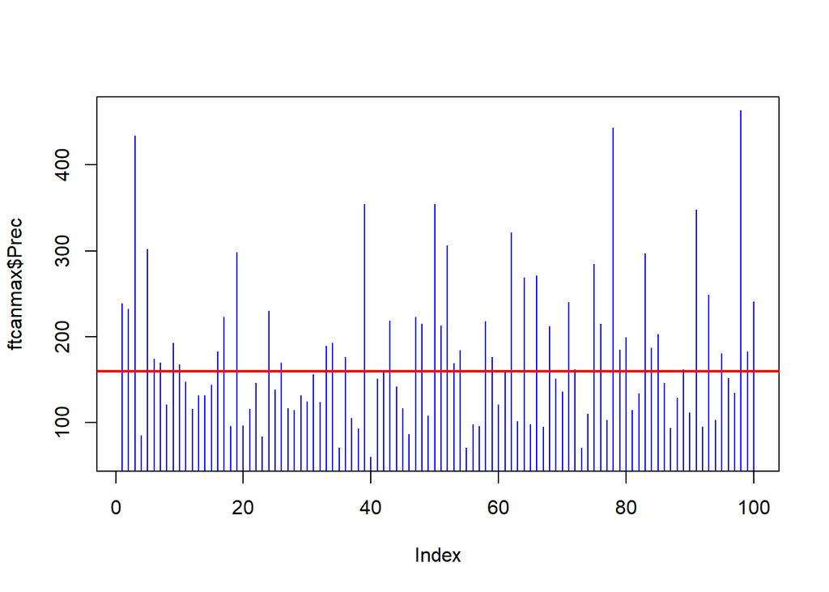

```r
plot(ftcanmax$Prec,type="h",col="blue")
abline(h=160, col="red",lwd=2)
```

# On a choisit un seuil ni trop grand, ni trop petit, cela nous permettra de faire un compromis de biais-variance.

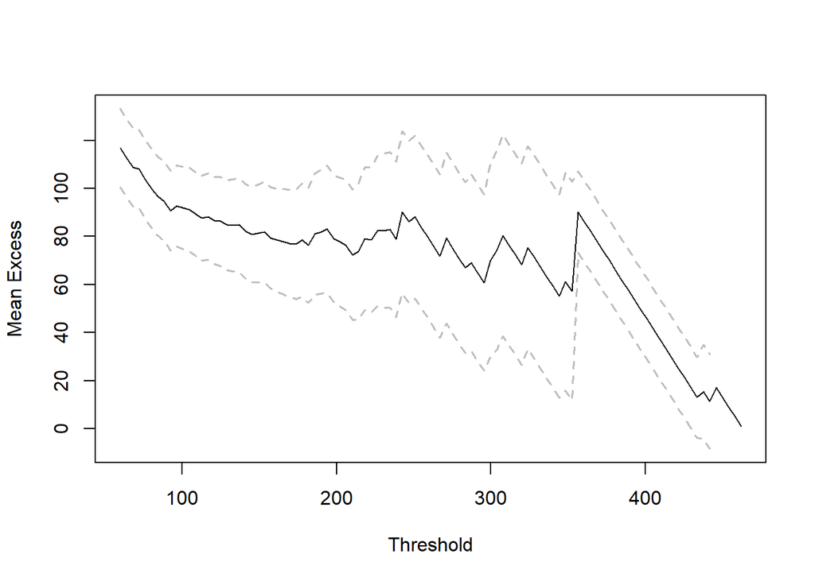

```r
mrlplot(ftcanmax$Prec)
```

# On a choisit un seuil de u=160 sur la partie linéaire entre 150 et 190 de la courbe du milieu.

```r
# methode de maximum de vraissemblance
#Fréchet
FitxthreshMle=fevd(x,threshold=160,type="GP",method="MLE",time.units="4/year")
FitxthreshMle
```

```
##
## fevd(x = x, threshold = 160, type = "GP", method = "MLE", time.units = "4/year")
##
## [1] "Estimation Method used: MLE"
##
##
##  Negative Log-Likelihood Value:  262.7627
##
##
##  Estimated parameters:
##        scale        shape
## 7.580400e+01 1.672096e-07
##
##  Standard Error Estimates:
##      scale      shape
## 15.3118196  0.1701988
##
##  Estimated parameter covariance matrix.
##            scale       shape
## scale 234.451819 -1.95318907
## shape  -1.953189  0.02896764
##
##  AIC = 529.5255
##
##  BIC = 533.3091
```

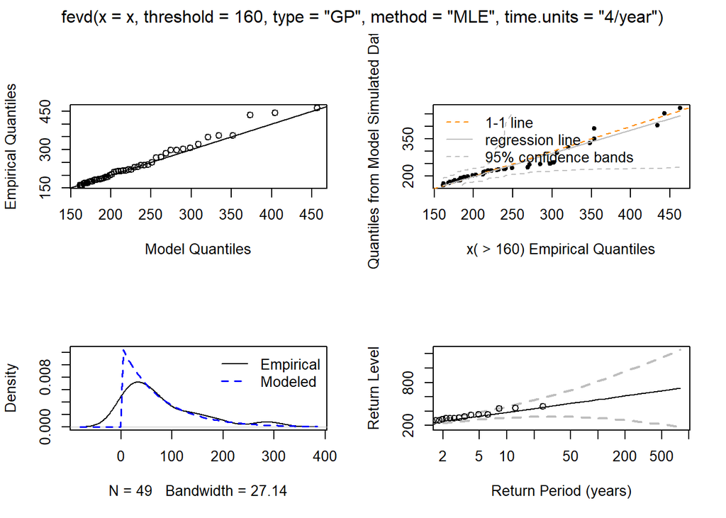

```r
plot(FitxthreshMle)
```

# Sur le graphique en bas à droite, on remarque que tous les points sont dans l’intervalle de confiance et assez bien alignés sur la courbe, on a un bon ajustement de notre modèle à nos données.Sur les graphiques en haut à gauche et en bas à gauche on voit un bon ajustement de notre modèle à nos données à part quelques points sous estimés.

```r
# return level plot
ci(FitxthreshMle,type="return.level",return.period = 200)
```

```
## fevd(x = x, threshold = 160, type = "GP", method = "MLE", time.units = "4/year")
##
## [1] "Normal Approx."
##
## [1] "200-year return level: 612.646"
##
## [1] "95% Confidence Interval: (274.3469, 950.9447)"
```

# on voit que l’intervalle de confiance est assez grand.

```r
# Gumbel
FitxthreshExpMle=fevd(x,threshold=160,type="Exponential",
                      method="MLE",time.units="4/year")
FitxthreshExpMle
```

```
##
## fevd(x = x, threshold = 160, type = "Exponential", method = "MLE",
##     time.units = "4/year")
##
## [1] "Estimation Method used: MLE"
##
##
##  Negative Log-Likelihood Value:  262.7345
##
##
##  Estimated parameters:
##    scale
## 78.40816
##
##  Standard Error Estimates:
##    scale
## 11.20117
##
##  Estimated parameter covariance matrix.
##          scale
## scale 125.4662
##
##  AIC = 527.4689
##
##  BIC = 529.3608
```

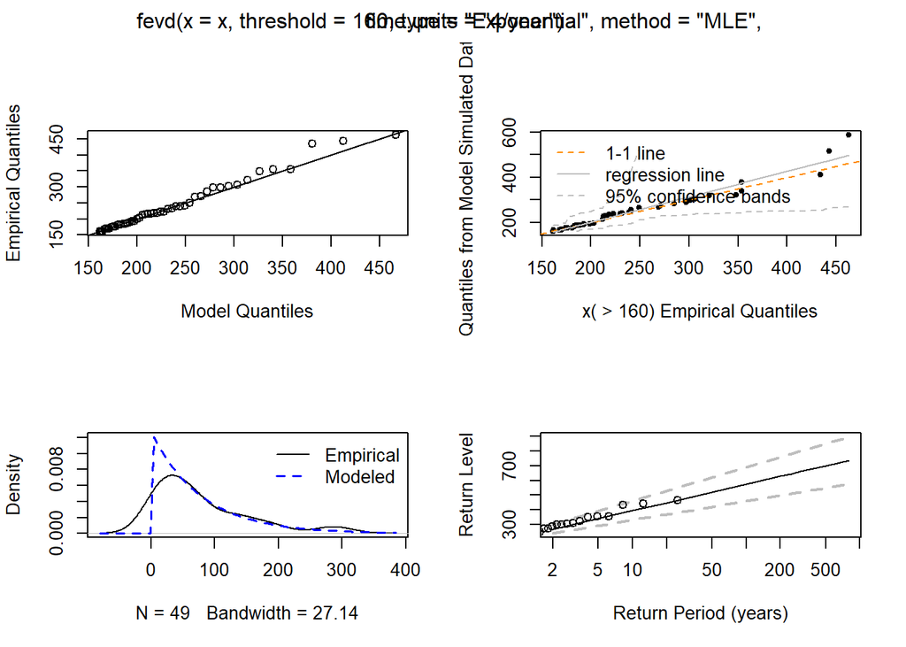

```r
plot(FitxthreshExpMle)
```

# Sur le graphique en bas à droite, on voit que tous les points sont dans l’intervalle de confiance et assez bien alignés sur la courbe, on a un bon ajustement de notre modèle à nos données . sur les graphiques en haut à gauche et en bas à gauche on voit un bon ajustement de notre modèle à nos données à part quelques points sous estimés.

```r
# return level plot
ci(FitxthreshExpMle,type="return.level",return.period = 200)
```

```
## fevd(x = x, threshold = 160, type = "Exponential", method = "MLE",
##     time.units = "4/year")
##
## [1] "Normal Approx."
##
## [1] "200-year return level: 628.196"
##
## [1] "95% Confidence Interval: (497.1032, 759.2881)"
```

# On voit que l’intervalle de confiance est moins grand que celui de Fréchet.

```r
# methode de moment
FitxthreshMoments=fevd(x,threshold=160,type="GP",method="Lmoments",time.units="4/year")
FitxthreshMoments
```

```
## fevd(x = x, threshold = 160, type = "GP", method = "Lmoments",
##     time.units = "4/year")
## [1] "GP  Fitted to  x  using L-moments estimation."
##       scale       shape
## 76.05952007  0.02995406
```

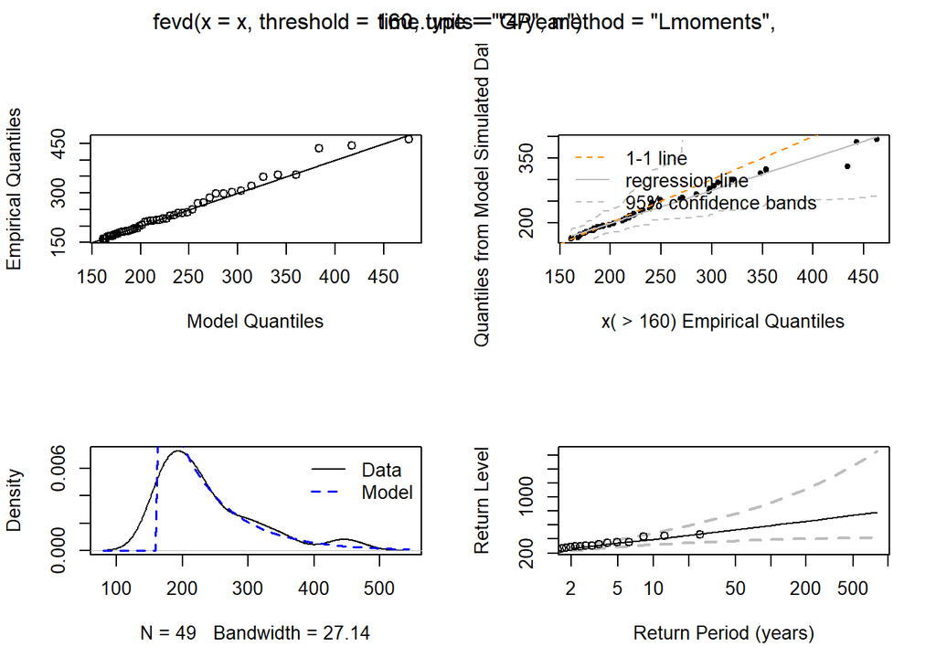

```r
plot(FitxthreshMoments)
```

# En regardant le graphique ci -dessus: sur celui d’en bas à droite, tous les points sont dans l’intervalle de confiance et assez bien alignés sur la courbe, on a un bon ajustement de notre modèle à nos données.Sur celui d’en haut à gauche et celui d’en bas à gauche on voit un bon ajustement de notre modèle à nos données à part quelques points sous estimés.

```r
# return level plot
ci(FitxthreshMoments,type="return.level",return.period = 200)
```

```
## fevd(x = x, threshold = 160, type = "GP", method = "Lmoments",
##     time.units = "4/year")
##
## [1] "Parametric Bootstrap"
## 502  iterations
##
## [1] "200-year level: 657.323"
##
## [1] "95% Confidence Interval: (400.8053, 1102.0491)"
```

# Résumé GP

```r
Tableaux2=data.frame(dataset=c("ftcanmax GP","ftcanmax GP"), Max=463,Method_of_estimation=c("Mle","Moments"),Fréchet=c(612.646,657.323),
                     Gumbel=c(628.196,"X"))
kable(Tableaux2,format = "simple")
```

| dataset | Max | Method_of_estimation | Fréchet | Gumbel |
| --- | --- | --- | --- | --- |
| ftcanmax GP | 463 | Mle | 612.646 | 628.196 |
| ftcanmax GP | 463 | Moments | 657.323 | X |

# Comparaison :GEV et GP

```r
Tableaux3=data.frame(dataset=c("ftcanmax GEV","ftcanmax GEV","ftcanmax GP","ftcanmax GP"), Max=463,Method_of_estimation=c("Mle","Moments","Mle","Moments"),Fréchet=c(597.437,560.302,612.646,657.323),
                     Gumbel=c(446.393,"X",628.196,"X"), Weibull=c("X","X"))
kable(Tableaux3,format = "simple")
```

| dataset | Max | Method_of_estimation | Fréchet | Gumbel | Weibull |
| --- | --- | --- | --- | --- | --- |
| ftcanmax GEV | 463 | Mle | 597.437 | 446.393 | X |
| ftcanmax GEV | 463 | Moments | 560.302 | X | X |
| ftcanmax GP | 463 | Mle | 612.646 | 628.196 | X |
| ftcanmax GP | 463 | Moments | 657.323 | X | X |